# Problem Set 3

Adam Wawrowski

4/3/2022

# Answer 1

1. Best subset selection will have the least training RSS, because it will incorporate all of the combinations of k predictors.
2. Best subset selection is more probably to have the smallest test RSS, but any of the selection methods could have the smallest by pure chance.
3. 1. True. All answers are by definition.
   2. True.
   3. False.
   4. False.
   5. False.

# Answer 2

1. 3. is correct. The lasso is less flexible than least squares due to a constraint on coefficients. This method is preferred when there is less overfitting resulting in a larger decrease in variance than the increase in bias.
2. 3. is correct. The same reasons that the Lasso is (iii).
3. 2. is correct. Non-linear models are inherently more flexible than least squares. Non-linear models are preferred when the increase in variance due to possible overfitting is less than the decrease in bias.

# Answer 3

1. 3. is correct. As increases, flexibility will decrease.
2. 2. is correct. As increase, variance and bias will interchange until a certain point where the test RSS is at its minimum. Then it will increase.
3. 4. is correct. As increase, flexibility will decrease, and variance will always decrease.
4. 3. is correct. As increase, flexibility will decrease, and variance will always decrease, and bias will always increase.
5. 22. is correct. Nothing can change the irreducible error.

# Answer 4

```r
College <- read.csv("College.csv")
rownames(College) <- College[, 1]
rownames(College) <- College[, 1]
College <- College[, -1]
```

```r
set.seed(1)
index <- sample(nrow(College), 0.5*nrow(College))
train <- College[index, ]
test <- College[-index, ]
```

```r
modelFit = lm(Apps ~ ., data=train)
summary(modelFit)
```

```
##
## Call:
## lm(formula = Apps ~ ., data = train)
##
## Residuals:
##     Min      1Q  Median      3Q     Max
## -5741.2  -479.5    15.3   359.6  7258.0
##
## Coefficients:
##               Estimate Std. Error t value Pr(>|t|)
## (Intercept) -7.902e+02  6.381e+02  -1.238 0.216410
## PrivateYes  -3.070e+02  2.006e+02  -1.531 0.126736
## Accept       1.779e+00  5.420e-02  32.830  < 2e-16 ***
## Enroll      -1.470e+00  3.115e-01  -4.720 3.35e-06 ***
## Top10perc    6.673e+01  8.310e+00   8.030 1.31e-14 ***
## Top25perc   -2.231e+01  6.533e+00  -3.415 0.000708 ***
## F.Undergrad  9.269e-02  5.529e-02   1.676 0.094538 .
## P.Undergrad  9.397e-03  5.493e-02   0.171 0.864275
## Outstate    -1.084e-01  2.700e-02  -4.014 7.22e-05 ***
## Room.Board   2.115e-01  7.224e-02   2.928 0.003622 **
## Books        2.912e-01  3.985e-01   0.731 0.465399
## Personal     6.133e-03  8.803e-02   0.070 0.944497
## PhD         -1.548e+01  6.681e+00  -2.316 0.021082 *
## Terminal     6.415e+00  7.290e+00   0.880 0.379470
## S.F.Ratio    2.283e+01  2.047e+01   1.115 0.265526
## perc.alumni  1.134e+00  6.083e+00   0.186 0.852274
## Expend       4.857e-02  1.619e-02   2.999 0.002890 **
## Grad.Rate    7.490e+00  4.397e+00   1.703 0.089324 .
## ---
## Signif. codes:  0 '***' 0.001 '**' 0.01 '*' 0.05 '.' 0.1 ' ' 1
##
## Residual standard error: 1083 on 370 degrees of freedom
## Multiple R-squared:  0.9389, Adjusted R-squared:  0.9361
## F-statistic: 334.3 on 17 and 370 DF,  p-value: < 2.2e-16
```

```r
modelPredict=predict(modelFit, newdata=test)
error=mean((test$Apps-modelPredict)^2)
error
```

```
## [1] 1135758
```

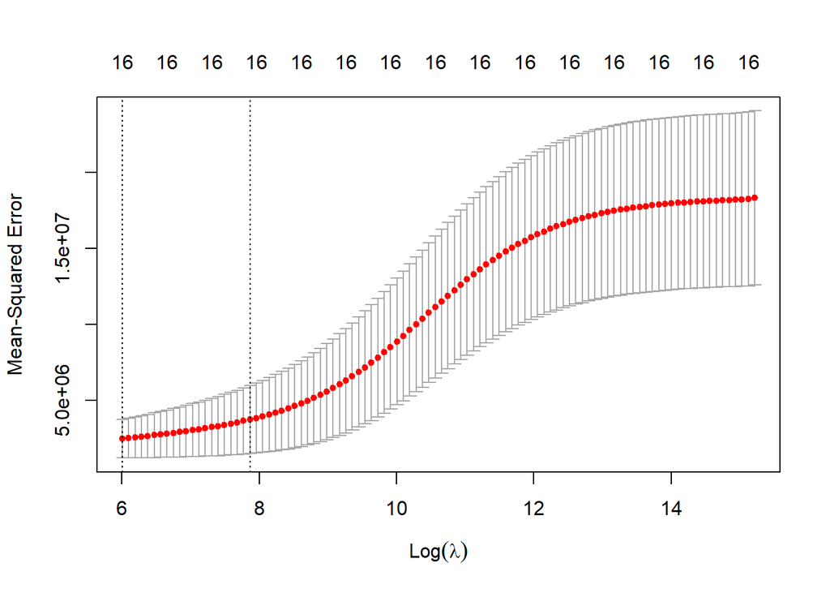

```r
set.seed(1)
xtrain = model.matrix(Apps~., data=train[,-1])
ytrain = train$Apps
xtest = model.matrix(Apps~., data=test[,-1])
ytest = test$Apps

ridgeFit = cv.glmnet(xtrain, ytrain, alpha = 0)
plot(ridgeFit)
```

```r
ridgeLambda = ridgeFit$lambda.min
ridgeLambda
```

```
## [1] 405.8404
```

Now we can fit the ridge regression use the lambda found by cross-validation.

```r
ridgePredict = predict(ridgeFit, s = ridgeLambda, newx = xtest)
ridgeError = mean((ridgePredict-ytest)^2)
ridgeError
```

```
## [1] 1007688
```

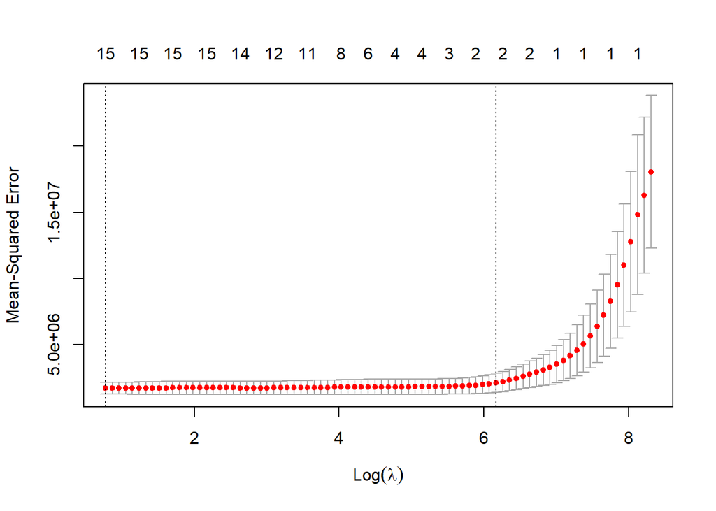

```r
set.seed(1)
lassoFit = cv.glmnet(xtrain, ytrain, alpha=1)
plot(lassoFit)
```

```r
lassoLambda = lassoFit$lambda.min
lassoLambda
```

```
## [1] 2.165848
```

We can now find the Lasso model using this lambda.

```r
lassoPredict = predict(lassoFit, s = lassoLambda, newx = xtest)
lassoError = mean((lassoPredict-ytest)^2)
lassoError
```

```
## [1] 1140473
```

This test error is higher than the error of the ridge regression.

```r
lassoCoeff = predict(lassoFit, type="coefficients", s=lassoLambda)[1:18,]
lassoCoeff
```

```
##   (Intercept)   (Intercept)        Accept        Enroll     Top10perc
## -1.082409e+03  0.000000e+00  1.760769e+00 -1.356850e+00  6.472719e+01
##     Top25perc   F.Undergrad   P.Undergrad      Outstate    Room.Board
## -2.052477e+01  9.044028e-02  1.388779e-02 -1.187542e-01  2.033676e-01
##         Books      Personal           PhD      Terminal     S.F.Ratio
##  2.591197e-01  0.000000e+00 -1.351004e+01  6.464269e+00  2.776541e+01
##   perc.alumni        Expend     Grad.Rate
## -1.445862e-02  5.025451e-02  6.605791e+00
```

# Answer 5

```r
X = rnorm(100)
eps = rnorm(100)
```

```r
Y = 1 + 2*X + 3*I(X^2) + 4*(X^3) + eps
head(Y)
```

```
## [1]  2.3850458  2.9544524 34.4043587  1.5965893 -2.8645296  0.9598009
```

[output not shown]

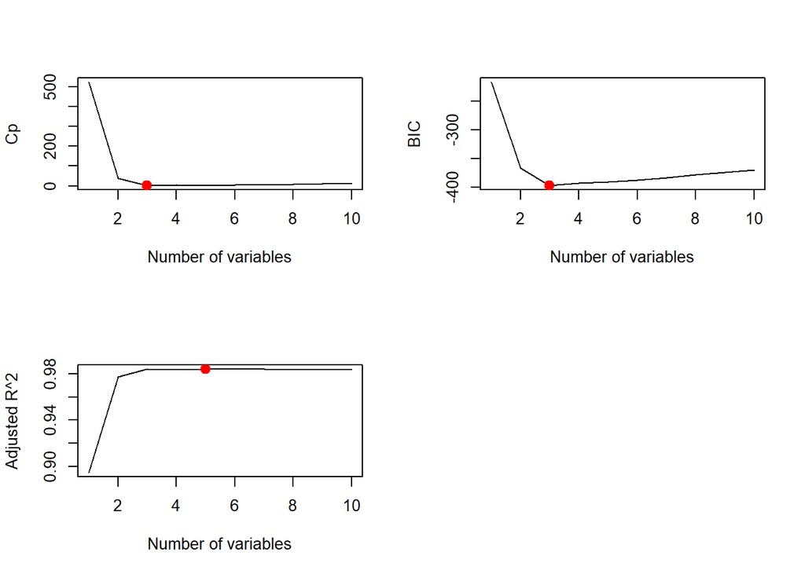

```r
full <- data.frame(y = X, x = Y)
regfitFull <- regsubsets(Y ~ X + I(X^2) + I(X^3) + I(X^4) + I(X^5) + I(X^6) + I(X^7) + I(X^8) + I(X^9) + I(X^10), data = full, nvmax = 10)

regSummary <- summary(regfitFull)
par(mfrow = c(2, 2))

plot(regSummary$cp, xlab = "Number of variables", ylab = "Cp", type = "l")
points(which.min(regSummary$cp), regSummary$cp[which.min(regSummary$cp)], col = "red", cex = 2, pch = 20)

plot(regSummary$bic, xlab = "Number of variables", ylab = "BIC", type = "l")
points(which.min(regSummary$bic), regSummary$bic[which.min(regSummary$bic)], col = "red", cex = 2, pch = 20)

plot(regSummary$adjr2, xlab = "Number of variables", ylab = "Adjusted R^2", type = "l")
points(which.max(regSummary$adjr2), regSummary$adjr2[which.max(regSummary$adjr2)], col = "red", cex = 2, pch = 20)

coef(regfitFull, which.max(regSummary$adjr2))
```

From this, we can conclude that the model with 3 predictors is the best model, where:

```
## (Intercept)           X      I(X^2)      I(X^3)
##   0.9825173   1.8640614   2.9992624   4.0855362
```

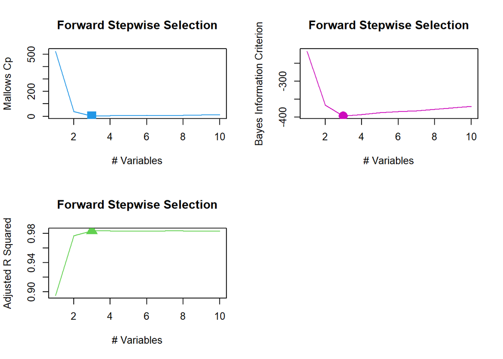

```r
regfitForward <- regsubsets(Y ~ X + I(X^2) + I(X^3) + I(X^4) + I(X^5) + I(X^6) + I(X^7) + I(X^8) + I(X^9) + I(X^10), data = full, nvmax = 10, method="forward")
regsumForward <- summary(regfitForward)

par(mfrow=c(2,2))

plot(regsumForward$cp, type="l", col=4, main="Forward Stepwise Selection", xlab = "# Variables", ylab = "Mallows Cp")
points(which.min(regsumForward$cp),regsumForward$cp[which.min(regsumForward$cp)], col=4, pch = 15, cex=2)

plot(regsumForward$bic, type="l", col=6, main="Forward Stepwise Selection", xlab = "# Variables", ylab = "Bayes Information Criterion")
points(which.min(regsumForward$bic),regsumForward$bic[which.min(regsumForward$bic)], col=6, pch = 16, cex=2)

plot(regsumForward$adjr2, type="l", col=3, main="Forward Stepwise Selection", xlab = "# Variables", ylab = "Adjusted R Squared")
points(which.max(regsumForward$adjr2),regsumForward$adjr2[which.max(regsumForward$adjr2)], col=3, pch = 17, cex=2)

coef(regfitForward,which.min(regsumForward$bic))
```

[output not shown]

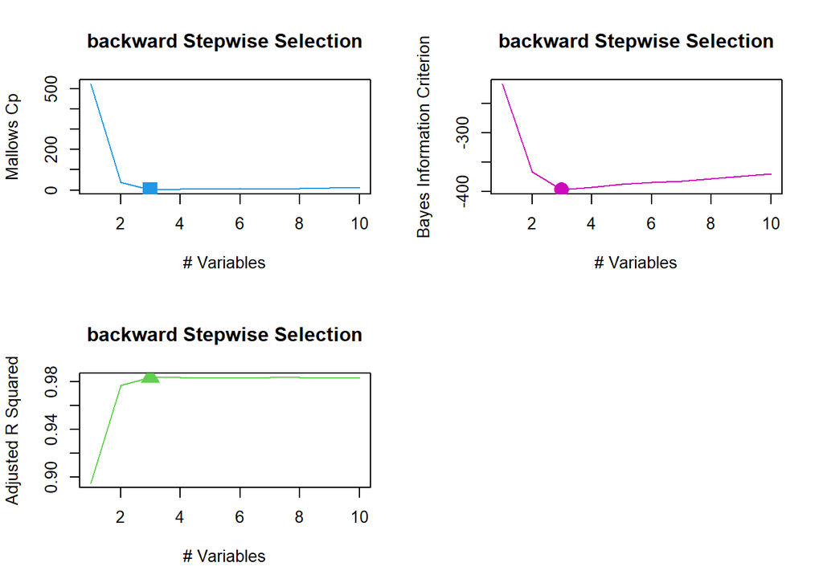

```r
regfitBkwd <- regsubsets(Y ~ X + I(X^2) + I(X^3) + I(X^4) + I(X^5) + I(X^6) + I(X^7) + I(X^8) + I(X^9) + I(X^10), data = full, nvmax = 10, method="forward")
regsumBwkd <- summary(regfitBkwd)

par(mfrow=c(2,2))

plot(regsumBwkd$cp, type="l", col=4, main="backward Stepwise Selection", xlab = "# Variables", ylab = "Mallows Cp")
points(which.min(regsumBwkd$cp),regsumBwkd$cp[which.min(regsumBwkd$cp)], col=4, pch = 15, cex=2)

plot(regsumBwkd$bic, type="l", col=6, main="backward Stepwise Selection", xlab = "# Variables", ylab = "Bayes Information Criterion")
points(which.min(regsumBwkd$bic),regsumBwkd$bic[which.min(regsumBwkd$bic)], col=6, pch = 16, cex=2)

plot(regsumBwkd$adjr2, type="l", col=3, main="backward Stepwise Selection", xlab = "# Variables", ylab = "Adjusted R Squared")
points(which.max(regsumBwkd$adjr2),regsumBwkd$adjr2[which.max(regsumBwkd$adjr2)], col=3, pch = 17, cex=2)

coef(regfitBkwd,which.min(regsumBwkd$bic))
```

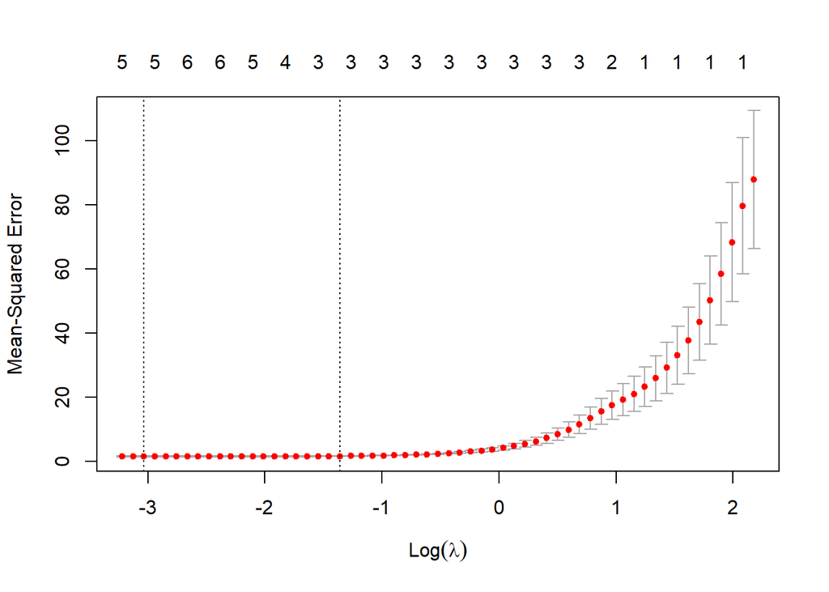

```r
xMat <- model.matrix(Y ~ X + I(X^2) + I(X^3) + I(X^4) + I(X^5) + I(X^6) + I(X^7) + I(X^8) + I(X^9) + I(X^10), data = full)[, -1]

cvLasso <- cv.glmnet(xMat, Y, alpha = 1)
plot(cvLasso)
```

```r
bestLambda <- cvLasso$lambda.min
bestLambda
```

```
## [1] 0.04813649
```

```r
predict(cvLasso, s = bestLambda, type = "coefficients")[1:11, ]
```

```
##  (Intercept)            X       I(X^2)       I(X^3)       I(X^4)       I(X^5)
## 1.0292062758 1.8218354794 2.9219797624 4.0748222497 0.0000000000 0.0000000000
##       I(X^6)       I(X^7)       I(X^8)       I(X^9)      I(X^10)
## 0.0013054864 0.0000000000 0.0005562603 0.0000000000 0.0000000000
```

```r
newY = 1 + 7 * I(X^7) + eps
newFull = data.frame(y = newY, x = X)

newRegFit <- regsubsets(newY ~ X + I(X^2) + I(X^3) + I(X^4) + I(X^5) + I(X^6) + I(X^7) + I(X^8) + I(X^9) + I(X^10), data = newFull, nvmax = 10)
newRegSum <- summary(newRegFit)

par(mfrow=c(2,2))

plot(newRegSum$cp, type="l", col=4, main = "Best Subset", xlab = "# Variables", ylab = "Cp")
points(which.min(newRegSum$cp),newRegSum$cp[which.min(newRegSum$cp)], col=4, pch = 15, cex=2)

plot(newRegSum$bic, type="l", col=6, main = "Best Subset", xlab = "# Variables", ylab = "BIC")
points(which.min(newRegSum$bic),newRegSum$bic[which.min(newRegSum$bic)], col=6, pch = 16, cex=2)

plot(newRegSum$adjr2, type="l", col=3, main = "Best Subset", xlab = "# Variables", ylab = "Adjusted R^2")
points(which.max(newRegSum$adjr2),newRegSum$adjr2[which.max(newRegSum$adjr2)], col=3, pch = 17, cex=2)

coef(newRegFit, which.min(newRegSum$cp))
```

```
## (Intercept)      I(X^7)
##   0.9797562   7.0039958
```

```r
coef(newRegFit, which.min(newRegSum$bic))
```

```
## (Intercept)      I(X^7)
##   0.9797562   7.0039958
```

```r
coef(newRegFit,which.max(newRegSum$adjr2))
```

```
## (Intercept)      I(X^7)
##   0.9797562   7.0039958
```

[figure not shown]

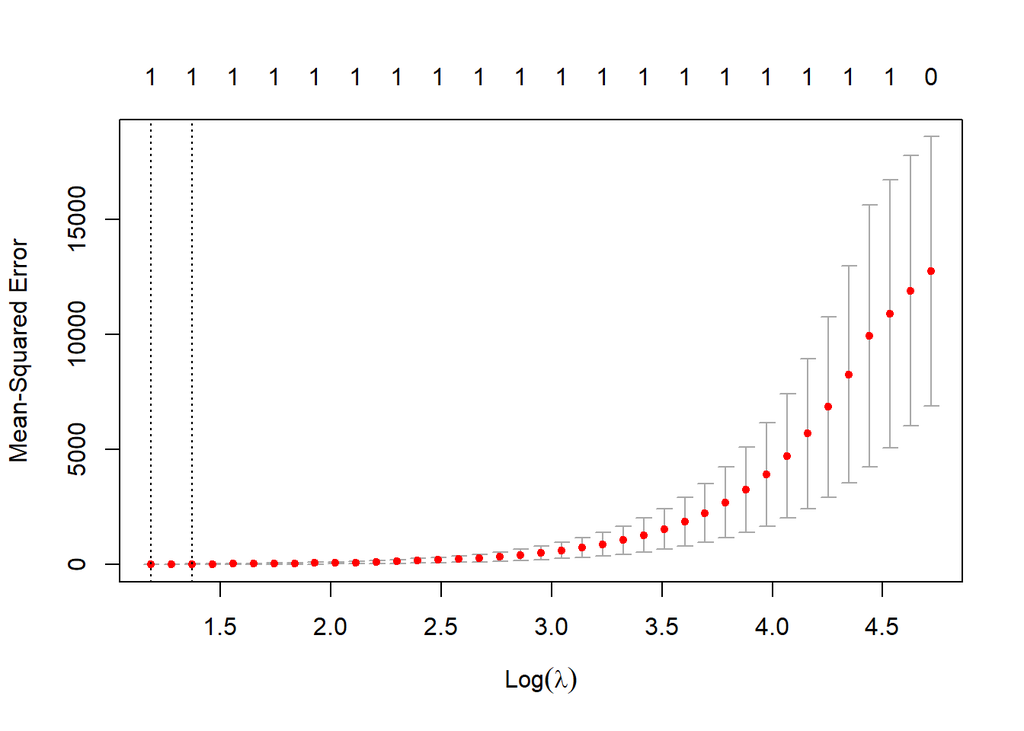

```r
xMat <- model.matrix(y ~ X + I(X^2) + I(X^3) + I(X^4) + I(X^5) + I(X^6) + I(X^7) + I(X^8) + I(X^9) + I(X^10), data = newFull)[, -1]

cvLasso <- cv.glmnet(xMat, newY, alpha = 1)
plot(cvLasso)
```

```r
bestLambda <- cvLasso$lambda.min
bestLambda
```

```
## [1] 3.267201
```

```r
predict(cvLasso, s = bestLambda, type = "coefficients")[1:11, ]
```

```
## (Intercept)           X      I(X^2)      I(X^3)      I(X^4)      I(X^5)
##    1.022006    0.000000    0.000000    0.000000    0.000000    0.000000
##      I(X^6)      I(X^7)      I(X^8)      I(X^9)     I(X^10)
##    0.000000    6.799826    0.000000    0.000000    0.000000
```